# STATS 531 Homework 7

Haiming Li

Due 2025-04-02

## Question 7.1

1. One slight issue is that I initially confused the usage of “#” as comment, but actually I’m supposed to have it to specify sbatch parameters. I spend some time trying to understand the sbtach file syntax, but overall it was smooth.
2. Yes, but not with slurm or any job submission tools.
3. Here’s the result from my local machine

   |  | user.self | sys.self | elapsed | user.child | sys.child |
   | --- | --- | --- | --- | --- | --- |
   | time0 | 2.448 | 0.078 | 2.527 | 0.000 | 0.000 |
   | time1 | 0.068 | 0.184 | 0.844 | 2.431 | 0.235 |
   | time2 | 0.157 | 0.317 | 1.637 | 0.446 | 0.053 |
   | time3 | 0.248 | 0.382 | 1.742 | 3.992 | 0.807 |
   | time4 | 0.569 | 0.330 | 1.951 | 4.057 | 0.690 |

   Here’s the result from greatlakes

   |  | user.self | sys.self | elapsed | user.child | sys.child |
   | --- | --- | --- | --- | --- | --- |
   | time0 | 5.435 | 0.334 | 5.787 | 0.000 | 0.000 |
   | time1 | 0.181 | 0.928 | 2.007 | 0.000 | 0.000 |
   | time2 | 0.168 | 0.843 | 1.352 | 2.169 | 0.639 |
   | time3 | 0.290 | 0.635 | 1.292 | 5.869 | 1.897 |
   | time4 | 1.058 | 1.122 | 2.466 | 5.971 | 2.558 |

## Question 7.2

1. I’ve adopted the SIR and SEIR model code from lecture 13<sup>[1]</sup> slides, and I’ve got the general setup code for particle filter and the run level from lecture 14<sup>[2]</sup> and lecture 15<sup>[3]</sup> slides.

   ```r
   seir_step <- Csnippet("
     double dN_SE = rbinom(S,1-exp(-Beta*I/N*dt));
     double dN_EI = rbinom(E,1-exp(-mu_EI*dt));
     double dN_IR = rbinom(I,1-exp(-mu_IR*dt));
     S -= dN_SE;
     E += dN_SE - dN_EI;
     I += dN_EI - dN_IR;
     R += dN_IR;
     H += dN_IR;
   ")

   seir_rinit <- Csnippet("
     S = nearbyint(eta*N);
     E = 0;
     I = 1;
     R = nearbyint((1-eta)*N);
     H = 0;
   ")

   measSEIR <- pomp(measSIR,
     rprocess=euler(seir_step,delta.t=1/7),
     rinit=seir_rinit,
     paramnames=c("N","Beta","mu_EI","mu_IR","eta","k","rho"),
     partrans=parameter_trans(
           log=c("Beta","mu_EI","mu_IR","k"),
           logit=c("eta","rho")
     ),
     statenames=c("S","E","I","R","H")
   )

   read_csv("measles_params.csv", show_col_types = FALSE) %>%
     filter(
       loglik==max(loglik),
       abs(mu_IR-2)<0.001
       ) %>%
     select(-loglik,-loglik.se) -> coef(measSEIR)
   coef(measSEIR,"mu_EI") <- 0.8
   fixed_params <- coef(measSEIR,c("N","mu_IR","k"))
   ```

   Here are the log-likelihoods from the SEIR model local search, which are are around -104. These log-likelihoods are evaluated via particle filter.

   ```r
   foreach(i=1:Nlocal,.combine=c,
   .options.future=list(seed=12138)
   ) %dofuture% {
   measSEIR |>
   mif2(
   Np=2000, Nmif=50,
   cooling.fraction.50=0.5,
   rw.sd=rw_sd(Beta=0.02, rho=0.02, mu_EI=0.02, eta=ivp(0.02)),
   partrans=parameter_trans(log=c("Beta", "mu_EI"),logit=c("rho","eta")),
   paramnames=c("Beta","rho","eta", "mu_EI")
   )
   } -> mifs_local

   registerDoRNG(12138)
   foreach(mf=mifs_local,.combine=rbind) %dopar% {
     library(pomp)
     library(tidyverse)
     evals <- replicate(Nreps_eval, logLik(pfilter(mf,Np=Np)))
     ll <- logmeanexp(evals,se=TRUE)
     mf %>% coef() %>% bind_rows() %>%
       bind_cols(loglik=ll[1],loglik.se=ll[2])
   } -> local_logliks
   summary(unname(local_logliks$loglik))
   ```

   ```
   ##    Min. 1st Qu.  Median    Mean 3rd Qu.    Max.
   ##  -104.8  -104.7  -104.6  -104.6  -104.5  -104.4
   ```

   Here are the results from the global search. The distributions are a bit more noisy than the local search, but the best result improves the loglikelihood by around 1 unit.

   ```r
   set.seed(12138)
   runif_design(
     lower=c(Beta=5,rho=0.2,eta=0,mu_EI=1/3),
     upper=c(Beta=80,rho=0.9,eta=1,mu_EI=3),
     nseq=Nglobal
   ) -> guesses
   mf1 <- mifs_local[[1]]

   registerDoRNG(12138)
   bake(file=paste0(results_dir,"global_search.rds"),{
   foreach(guess=iter(guesses,"row"), .combine=rbind) %dopar% {
     library(pomp)
     library(tidyverse)
     mf1 %>%
       mif2(params=c(unlist(guess),fixed_params),Np=Np) %>%
       mif2() -> mf
     replicate(
       Nreps_eval,
       mf %>% pfilter(Np=Np) %>% logLik()
     ) %>%
       logmeanexp(se=TRUE) -> ll
     mf %>% coef() %>% bind_rows() %>%
       bind_cols(loglik=ll[1],loglik.se=ll[2])
   } -> results
   }) %>%
     filter(is.finite(loglik)) -> results
   summary(results$loglik)
   ```

   ```
   ##    Min. 1st Qu.  Median    Mean 3rd Qu.    Max.
   ##  -345.8  -118.4  -115.7  -120.6  -104.2  -103.7
   ```

2. The improvement of SEIR is only about 1 unit of log-likelihood. (the best SIR log-likelihood is around -104) This improvement is probably not practically significant, which suggest that adding the $E$ parameter not necessarily help with capturing the variability of the data.
3. From the lecture slide, the correlations between these parameters in SIR model are mostly linear. However, under the SEIR model, the correlations are mostly non-linear. Also, the range of optimal $\rho$ and $\eta$ has also changed significantly from the SIR model. Overall, by adding an latent state, although the fitness of the model did not change much, the meaning of each fitted parameters may have very different interpretations.

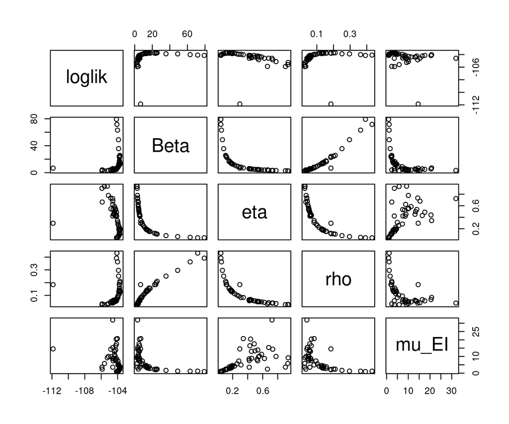

   ```r
   pairs(~loglik+Beta+eta+rho+mu_EI,
         data=filter(results,loglik>max(loglik)-10))
   ```

[figure not shown]

   ```r
   filter(results,loglik>max(loglik)-5) %>% sapply(range) -> box
   freeze(seed=12138,
     profile_design(
       rho =seq(0.01,0.95,length=Npoints_profile),
       lower=box[1,c("Beta","eta","mu_EI")],
       upper=box[2,c("Beta","eta","mu_EI")],
       nprof=Nreps_profile, type="runif"
     )) -> guesses
   fixed_params <- c(N=20000, mu_IR=2, k=10)
   bake(file=paste0(results_dir,"rho_profile.rds"),dependson=guesses,{
     registerDoRNG(12138)
     foreach(guess=iter(guesses,"row"), .combine=rbind) %dopar% {
       library(pomp)
       library(tidyverse)
       mf1 %>% mif2(params=c(guess,fixed_params),Nmif=Nmif,
         rw.sd=rw_sd(Beta=0.02,eta=ivp(0.02),mu_EI=0.02)) %>%
         mif2(Nmif=Nmif,Np=Np,cooling.fraction.50=0.5) -> mf
       replicate(
         Nreps_eval,
         mf %>% pfilter(Np=Np) %>% logLik()) %>%
         logmeanexp(se=TRUE) -> ll
       mf %>% coef() %>% bind_rows() %>%
         bind_cols(loglik=ll[1],loglik.se=ll[2])
     } -> prof_results
   }) -> profile_results
   ```

## Acknowledgements

For question 7.2, I’ve heavily relied on the code from lecture 14<sup>[2]</sup> and lecture 15<sup>[3]</sup> slides, as well as the past year solution<sup>[4]</sup>. For the local search, I’ve modified the local search code in lecture 14 for SIR model to make it work with SEIR model. For figures, I’ve adopted them from lecture 15<sup>[3]</sup> notes.

## Reference

[1]

Ionides, E. L. (n.d.). Chapter 13 lecture note. Retrieved March 17, 2025, from https://ionides.github.io/531w25/13/slides.pdf

[2]

Ionides, E. L. (n.d.). Chapter 14 lecture note. Retrieved March 26, 2025, from https://kingaa.github.io/sbied/mif/slides.pdf

[3]

Ionides, E. L. (n.d.). Chapter 14 lecture note. Retrieved March 26, 2025, from https://kingaa.github.io/sbied/polio/slides.pdf

[4]

Ionides, E. L. (n.d.). Solution to homework 7. Retrieved March 26, 2025, from https://ionides.github.io/531w24/hw07/sol07.html